# Signal K Specification

Version 1.8.4 — signalk.org/specification

# Introduction

This is the documentation for the [Signal K Specification](https://github.com/signalk/specification) 1.8.4 version ([permalink](http://signalk.org/specification/1.8.4/doc/)).

## What is Signal K?

**Signal K** is a modern and open data format for marine use. It is an Internet friendly standard built on common web technologies, such as JSON and WebSockets. Signal K is Free and Open Source software. This document is licensed under the Creative Commons [CC-BY-SA](https://creativecommons.org/licenses/by-sa/4.0/) license. All Signal K source code is licensed under the [Apache License, Version 2.0](https://www.apache.org/licenses/LICENSE-2.0). Signal K is developed in the open with help from the marine community. Your ideas and feedback are valuable and welcome.

Signal K is designed to work in harmony with a boat’s existing navigation equipment which may use NMEA0183, NMEA2000 or proprietary data protocols, converting and enhancing this information into a modern “web friendly” format which can be shared, processed and displayed on the latest web apps, mobile devices and cloud servers. A typical NMEA based installation consists of an NMEA to Signal K gateway and an optional Signal K server. The gateway translates NMEA data into Signal K format and the server can host additional functions like logging, cloud integration and data analysis.

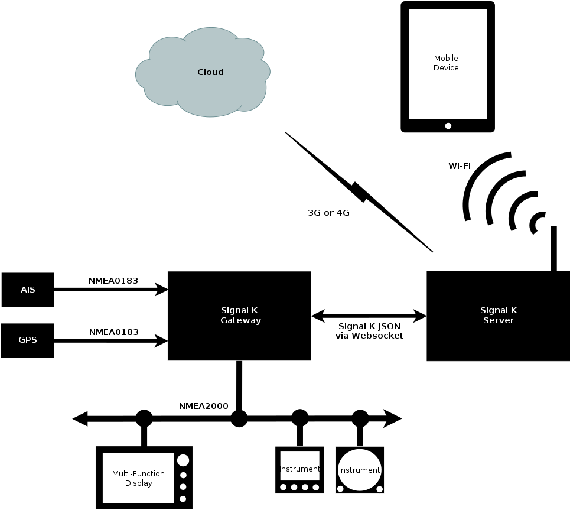

One major advantage of Signal K is the ability to represent data from heterogeneous sources. In addition to traditional NMEA sources, data from generic sensors as well as modern Signal K enabled sensors can be fused into a single data model and a single protocol for accessing the data. Another typical configuration is a Signal K server with adapters and converters for the different sources.

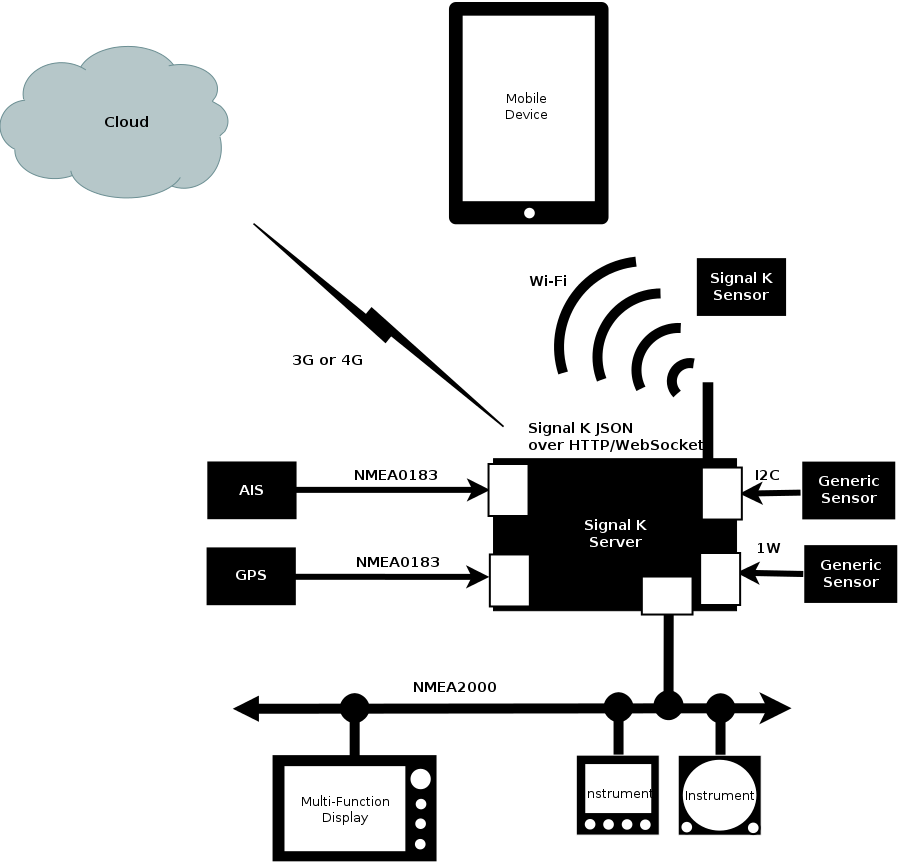

## Signal K Data Model (A.K.A. The Schema)

The Signal K Data Model or schema defines a universal model for marine related information and it is specified as a JSON schema. See the Signal K Data Model section for details.

In traditional marine standards there are many tightly defined messages, each with a specific purpose, but there is no data model to relate them. Furthermore, any device which needs to decode those messages must have a copy of the data dictionary in order to do so. By defining a data model in JSON we can make the messaging layer simpler and easily extensible. We define consistent units and meta data for each data point in the model. This means that a specific data point (e.g. COG) will always be found at a predictable address.

It also means that a display device such as a chartplotter implementing Signal K does not need to know about the data model beforehand. It can query the central Signal K server on the boat to get all the information it needs to display any data point. This **metadata** may include information such as the unit of measure, minimum and maximum permissible values, alarm thresholds and localized display name for every data point in the model.

### Signal K Message Format

Signal K defines methods for combining arbitrary data from the Data Model into valid messages. These messages are in UTF-8 JSON format.

Rather than define hundreds of specific messages, Signal K has a few common message formats which can contain any combination of data from the Data Model. This means that there is no need to define new messages for every new data point or command which needs to be supported, rather the message format remains the same and only the data transmitted needs to change. It means that any device can read any message and a device can introduce a new data point which can be understood by existing devices without the need for firmware upgrades.

## Signal K Transport Layer

Signal K does not define the transport or wire protocol. Signal K messages are JSON text and can be sent over almost any physical transport layer. However, the Signal K standard does provide guidance on how to establish an initial connection, handle negotiation, subscription, and disconnection for a given transport (e.g. TCP/IP or serial).

Where possible Signal K uses well established standards like HTTPS, REST, and WebSockets. However, these should not be interpreted as required dependencies of Signal K. It is entirely possible and permissible to implement the protocol over any transport that your implementation requires.

The goal is to try to establish sensible conventions for each transport in order to make development and interconnection more predictable.

## Signal K Implementations

The Signal K project has Open Source reference server implementations in [Node](https://github.com/SignalK/signalk-server-node) and [Java](https://github.com/SignalK/signalk-server-java). There are also several web apps provided by the project which can be installed directly in the Node and Java servers or downloaded from [Signal K GitHub](https://github.com/SignalK). There are also commercial [Signal K applications and solutions](http://signalk.org/applications_solutions.html), including mobile apps available on the Apple App and Android Play Stores, as well as hardware products like [iKommunicate](http://ikommunicate.com/).

# Getting Started Using Signal K

You can start using Signal K by

- connecting to the [demo server](http://demo.signalk.org/) on the Internet with any web browser
- installing [SK server](https://github.com/signalk/signalk-server-node) on any computer
- getting some hardware for your boat, such as a [Raspberry Pi](https://en.wikipedia.org/wiki/Raspberry_Pi), suitable USB adapters for your boat’s network ([NMEA 0183](http://digitalyacht.co.uk/product/usb-nmea-adaptor/), [NMEA 2000](https://github.com/SignalK/signalk-server/wiki/FAQ:-Frequently-Asked-Questions#how-do-i-integrate-with-nmea2000-can-bus) or roll your own with [I2C](https://en.wikipedia.org/wiki/I%C2%B2C) sensors) and installing the server
- For sensors over WiFi take a look at SensESP
- installing [OpenPlotter](https://openplotter.readthedocs.io/en/3.x.x/), which includes a Signal K server

Once you have a server running (or you start by using the demo server) you can install some Signal K supporting mobile apps such as [WilhelmSK](https://www.wilhelmsk.com/) (iOS).

# Getting Started in Developing with Signal K

- [Example HTML5 Applications](https://github.com/SignalK/signalk-server-node/tree/master/public/examples)
- [Signal K JavaScript Client](https://github.com/SignalK/signalk-js-client)
- [iKommunicate Developer’s Guide](https://github.com/digitalyacht/ikommunicate/wiki/iKommunicate-Developer%27s-Guide-%28SDK%29)

# Signal K Data Model

## Formats

Signal K defines two data formats—full and delta—for representing and transmitting data. All Signal K data is transmitted as UTF-8 JSON.

## Full Format

The full format is conceptually the simplest representation of data in Signal K. It contains all of the data from a Signal K node, which in the case of a Signal K server could be many hundreds of data points.

```json
{
  "version": "1.0.0",
  "self": "urn:mrn:signalk:uuid:705f5f1a-efaf-44aa-9cb8-a0fd6305567c",
  "vessels": {
    "urn:mrn:signalk:uuid:705f5f1a-efaf-44aa-9cb8-a0fd6305567c": {
      "navigation": {
        "speedOverGround": {
          "value": 4.32693662,
          "$source": "ttyUSB0.GP",
          "sentence": "RMC",
          "timestamp": "2017-05-16T05:15:50.007Z"
        },
        "position": {
          "value": {
            "altitude": 0.0,
            "latitude": 37.81479,
            "longitude": -122.44880152
          },
          "$source": "ttyUSB0.GP",
          "sentence": "RMC",
          "timestamp": "2017-05-16T05:15:50.007Z"
        },
        "headingMagnetic": {
          "value": 5.55014702,
          "$source": "ttyUSB0.II",
          "sentence": "HDM",
          "timestamp": "2017-05-16T05:15:54.006Z"
        }
      },
      "name": "Motu",
      "uuid": "urn:mrn:signalk:uuid:705f5f1a-efaf-44aa-9cb8-a0fd6305567c"
    }
  },
  "sources": {
    "ttyUSB0": {
      "label": "ttyUSB0",
      "type": "NMEA0183",
      "GP": {
        "talker": "GP",
        "sentences": {
          "RMC": "2017-04-03T06:14:04.451Z"
        }
      },
      "II": {
        "talker": "II",
        "sentences": {
          "HDM": "2017-05-16T05:15:54.006Z"
        }
      }
    }
  }
}
```

There are several top level attributes or keys which are always present and others which are optional. The `version` key specifies which version of the Signal K specification is being used and must always present in a full Signal K model. Also always present in the full model is the `self` key. The value of `self` is the key within the `vessels` object which is the local boat. Effectively, it is a pointer into the `vessels` object.

Below the `vessels` object is a list of vessels, identified by their MMSI number or a generated unique ID. There may be many vessels if data has been received from AIS or other sources. The format for each vessel’s data uses the same standard Signal K structure but may not have the same content; likely you will not have as much data about other vessels as you have about your own.

At the same level as `vessels` is `sources`. This contains a list of sources the data was obtained from. Each data object within a `vessel` may have a `$source` key which point to a source within `sources`. Several data objects may reference the same `source` since a single NMEA sentence or PGN may map to multiple keys in Signal K.

Alternatively the source data may be embedded directly in place of the `$source` by using the `source` key:

```json
{
  "vessels": {
    "urn:mrn:signalk:uuid:705f5f1a-efaf-44aa-9cb8-a0fd6305567c": {
      "navigation": {
        "position": {
          "value": {
            "altitude": 0.0,
            "latitude": 37.81479,
            "longitude": -122.44880152
          },
          "source": {
            "label": "ttyUSB0",
            "type": "NMEA0183",
            "talker": "GP",
            "sentence": "PRMC"
          },
          "timestamp": "2017-05-16T05:15:50.007Z"
        }
      }
    }
  }
}
```

For more information on sources, see the sources section.

Data objects in Signal K are organized hierarchically, for example data related to navigation such as position, speed through water and heading are all organized under a `navigation` sub-topic within the `vessel` object. Each data object has a `value` property which holds the actual value for that specific key. The `value` property may contain a number, a string or another object. Signal K keys that are object valued are object valued because the values don‘t have much semantic meaning individually. For example position – latitude doesn‘t have much meaning without an associated longitude. Therefore, these (and altitude) are grouped together in a single `navigation.position` key.

### Antenna offsets and lever-arm correction

GNSS antennas are rarely mounted at the vessel's reference point, and a vessel may have more than one antenna with different offsets. To keep `navigation.position` consistent across antennas, a Signal K server may apply a server-side lever-arm correction so a published position represents the **Common Coordinate Reference Point (CCRP)** rather than the raw antenna position. The CCRP is defined as the center of the vessel on the longitudinal centerline: body coordinates `(design.length.value.overall / 2, 0)` measured from the bow.

Offsets are expressed in a right-handed vessel body frame: **x forward** (toward the bow) and **y to starboard**. This is the same handedness as `navigation.attitude.yaw` and `navigation.rateOfTurn`, both of which are positive to starboard, so an offset and a heading can be combined without a sign correction.

Each antenna's mounting offset is described via `sensors.<id>.fromBow` (distance aft of the bow along the longitudinal axis) and `sensors.<id>.fromCenter` (perpendicular distance from the longitudinal centerline; positive to starboard, negative to port). The sensor instance is linked to its data stream via `sensors.<id>.$source`, which equals the `$source` value the device's measurements arrive with. These are descriptive metadata about geometry; consumers of `navigation.position` should **not** re-apply them client-side.

Lever-arm correction is a server option and is not part of the wire format — it changes only which position value(s) appear on `navigation.position`. A server with correction enabled applies configured offsets in one of two ways:

- **Replace** — a `navigation.position` update whose `$source` matches a configured antenna is published at the CCRP instead of at the antenna. The delta's `$source` is unchanged, so source-filtered subscriptions still see which antenna produced the fix. No additional fields are added to the update: position deltas are high volume, so the correction is not flagged in-band.
- **Both** — the antenna's own position passes through unchanged and the corrected position is additionally published as a separate source on `navigation.position` under `$source` `<id>.ccrp`. The two positions then coexist as distinct sources and consumers select between them via source priorities; the raw per-antenna measurement remains available as its own source.

Correction requires both a configured antenna offset and a current heading (`navigation.headingTrue`, or `navigation.headingMagnetic + magneticVariation`). When heading is unavailable the server publishes the antenna position as-is and, while a correction mode is active, raises a `notifications.navigation.gnss.headingUnavailable` notification so the condition is visible; the notification is cleared when heading returns.

The values are always SI units, and always the same units for the same key. Therefore, `speedOverGround` is always meters per second, never knots, km/hr, or miles/hr. This means you never have to send units with data, the units are specific for a key, and defined in the data schema. A simplified version of the JSON schema with the units is available in [Keys Reference in Appendix A](https://signalk.org/specification/1.8.4/doc/vesselsBranch.html). The units are also always specified in the values’ metadata which is available via the REST API in the `meta.units` property. Besides the `units` property, `meta` provides a lot of other useful information for consumers of the data.

Finally, each data object also has a `timestamp` property which represents the time that the value was measured. Timestamps are in ISO 8601 format – specifically the [RFC 3339](https://tools.ietf.org/html/rfc3339) extension format, which is slightly more strict than the ISO specification. For instance, it requires four digit years and specifies that `T` is used as a separator between the data and time portions of the timestamp.

The ordering of keys is also not important, they can occur in any order. In fact, if you are designing a device which consumes Signal K data, it is important to remember that the JSON standard does not guarantee the order of properties in an object. You MUST NOT rely on the data you receive to always be in the same order within a Signal K message.

The full format is most useful for getting the initial state of a Signal K system, for example when a display device first connects to the network or for refreshing a device‘s state when it loses a network connection.

However sending the full data model is wasteful of both bandwidth and CPU, especially when there is a large amount of available data, or the consuming device is only interested in a small portion of it. In the majority of cases, it is preferable to only exchange small, specific portions of the data.

## Delta Format

By far, the most commonly produced Signal K format is the delta format. Conceptually, the delta is an update to an existing Signal K data model. A device consuming deltas could either build up a view of the Signal K full tree by consuming and combining deltas or it could request from a Signal K server the current full tree model and apply deltas to that as they are received. It is also entirely possible for a device to remain essentially stateless and treat Signal K deltas as independent packets of data, much the same way as it would handle NMEA sentences or PGNs.

An example delta message is presented below.

```json
{
  "context": "vessels.urn:mrn:imo:mmsi:234567890",
  "updates": [
    {
      "source": {
        "label": "N2000-01",
        "type": "NMEA2000",
        "src": "017",
        "pgn": 127488
      },
      "timestamp": "2010-01-07T07:18:44Z",
      "values": [
        {
          "path": "propulsion.0.revolutions",
          "value": 16.341667
        },
        {
          "path": "propulsion.0.boostPressure",
          "value": 45500
        }
      ]
    }
  ]
}
```

The top level of a delta message contains an `updates` property and an optional `context` property.

```json
{
  "context": "vessels.urn:mrn:imo:mmsi:234567890",
  "updates": [...]
}
```

The optional `context` property roots the updates to a particular location in the Signal K tree. If `context` is missing it is assumed that the data is related to the `self` context. The `self` context is the `vessel` object which the `self` property of the full model points to.

Context is a path from the root of the full tree to the *container object*, which for vessel related data must refer to a vessel directly under `vessels`. The delimiter in the context path is `.` (period). In this case the context is `vessels.urn:mrn:imo:mmsi:234567890`. All subsequent data is relative to that location.

The `updates` property holds a JSON array of update objects, each of which may have a `source` property, a `timestamp` property and an array of `values` containing one or more value objects.

```json
{
  "source": {
    "label": "N2000-01",
    "type": "NMEA2000",
    "src": "115",
    "pgn": 128267
  },
  "timestamp": "2014-08-15T16:00:00.081Z",
  "values": [
    {
      "path": "navigation.courseOverGroundTrue",
      "value": 2.971
    },
    {
      "path": "navigation.speedOverGround",
      "value": 3.85
    }
  ]
}
```

An `update` has a single `source` value and it applies to each of the `values` items. In cases where data can only come from a single source, such as an NMEA 0183 talker connected to a serial port, then the source may be omitted. However, if the delta is being passed on by a Signal K server or multiplexer then `source` must be filled in by the server so that downstream consumers can discern where the update comes from.

In cases where a Signal K producer does not have access to a real time clock or GPS time then `timestamp` should be omitted. Elements in the Signal K processing chain-such as a server receiving data from a producer-should fill in timestamp if it is missing in the incoming delta message.

Each `value` item is then simply a pair of `path` and `value`. The `path` must be a *leaf path*: it must be a path to a leaf the of the full model. A leaf is where the actual value of the Signal K property is and where `timestamp`, `$source` and `values` properties are in the full model. The value is often a scalar-a single numeric value, as in the example above-but it can also be an object. For example a `navigation.position` value would be an object like `{"latitude": -41.2936935424, "longitude": 173.2470855712}`.

There are some static properties in the full model that lack the support for multiple values and metadata such as source and timestamp. An example is a vessel‘s name, directly under the vessel‘s root. This static data may appear in the delta stream, for example when received in AIS transmission. In this case the value should be the subtree of the full model, starting from the vessel's root, with just the relevant parts, and the path must be empty, indicating that the value should be merged to the full model mounted where the delta‘s context property points:

```json
{
  "context": "vessels.urn:mrn:imo:mmsi:234567890",
  "updates": [
    {
      "source": {...},
      "timestamp": "2014-08-15T19:02:31.507Z",
      "values": [
        {
          "path": "",
          "value": {
            "name": "WRANGO"
          }
        }
      ]
    }
  ]
}
```

## Delta Format For Metadata

Metadata can also be updated via a delta within the `meta` key.

Since meta data is not often updated it is only sent when there has been a change. See Subscription Protocol for details.

```json
{
  "context": "vessels.urn:mrn:imo:mmsi:234567890",
  "updates": [
    {
      "timestamp": "2014-08-15T19:02:31.507Z",
      "meta": [
        {
          "path": "environment.wind.speedApparent",
          "value": {
            "units": "m/s",
            "description": "Apparent wind speed",
            "displayName": "Apparent Wind Speed",
            "shortName": "AWS",
            "zones": [
              {
                "upper": 15.4333,
                "state": "warn",
                "message": "high wind speed"
              }
            ]
          }
        }
      ]
    }
  ]
}
```

## Data Quality

Data transmitted in Signal K format is assumed to be corrected for known sensor inaccuracies such as wind angle offset due to misalignment of a masthead unit on the mast, but there is no *guarantee* that data is accurate, or within certain bounds. Different sources will have different data quality and normal vigilance is always required.

## Missing or Invalid Data

A sensor or gateway/server may want to send a message indicating known invalid data or the fact that the sensor is functioning but can not provide data, for example when a depth sensor has no bottom fix. In this case the value must be JSON `null` in the delta message and the server must return the value as a JSON `null` in the REST API.

## Message Integrity

Many messaging systems specify checksums or other forms of message integrity checking. Signal K assumes a reliable transport will guarantee a valid message. This is true of TCP/IP and some other transports but not always the case. For other transports (e.g. RS-232 serial) a specific extended data format will apply, which is suited to that transport. Hence at the message level no checksum or other tests need to be made.

## Encoding/Decoding

The JSON message format is supported across most programming environments and can be handled with any convenient library.

On micro-controllers with limited RAM it may be necessary to read and write Signal K data using a streaming process rather than reading the entire message into RAM before processing. There is an implementation of Signal K JSON streaming on an Arduino Mega (4K RAM) in the related [Freeboard project](https://github.com/rob42/FreeboardMega/tree/signal_k_dev/lib/SignalK).

# Multiple Values for a Key

There are two use cases for multiple values for a single data point

- Multiple instances of a common device-e.g. two engines or multiple batteries.
- Multiple devices providing duplicate data-multiple values for the same Signal K key from different sensors. This is fairly common as most boats have multiple sensors capable of generating the same data (but not necessarily the same value). For example, course over ground (COG) may come from both a compass and GPS or a boat may be equipped with multiple depth sounders.

## Multiple Instances of a Common Device

Some parts of the Signal K schema are **device oriented**.

For example, many boats have multiple batteries. However each battery has multiple, common quantities like voltage, current and temperature. In this case, it makes more sense for these values to be organized by instance. Therefore, in the Signal K model, each battery bank is it’s own instance: for example `electrical.batteries.starter` and `electrical.batteries.house`. Then beneath that prefix there are the various properties for each battery.

This organisation allows a user interface to organise the individual readings in meaningful groups and allows consumers to query all the values related to that piece of equipment via the REST API. Furthermore, this structure maintains the primary requirement that a given data value have a fixed and unique URI, but gives flexibility in the structure and complexities of data.

The same device centric organisation is used within the `propulsion` subschema, to support the common use case of two engines via `propulsion.port` and `propulsion.starboard`.

> The values `starter`, `house`, `port` and `starboard` are examples and not specified in the schema. You are free to use application specific values within the regexp specified in the JSON schema.

## Multiple Devices Providing Duplicate Data

It is quite possible for a key value to come from more than one device. Many modern devices have a built in GPS receiver and as a result on any given boat there may be several sources of position, speed over ground, and heading. Multiple depth sounders are also common, often installed to port and starboard on monohull sailboats or in each hull of a catamaran.

Given that the validity of these various sources of data may change in a context-specific way, Signal K provides a mechanism for these values to be grouped together so that the consumer of the data may choose which value (or values) to display<sup>1</sup>.

When dealing with multiple sources of data, it becomes important to know where the data is coming from. Signal K provides a mechanism for that in the form of the `sources` top level object and references into that object via the `$source` property. See sources for detailed information on the structure of the `sources` object and how it is referenced by the `$source` property.

The first source of a particular data point becomes the default source for that data and a normal Signal K object is created.

```json
{
  "self": "urn:mrn:signalk:uuid:c0d79334-4e25-4245-8892-54e8ccc8021d",
  "version": "0.9.0",
  "vessels": {
    "urn:mrn:signalk:uuid:c0d79334-4e25-4245-8892-54e8ccc8021d": {
      "uuid": "urn:mrn:signalk:uuid:c0d79334-4e25-4245-8892-54e8ccc8021d",
      "navigation": {
        "courseOverGroundTrue": {
          "value": 3.61562407843144,
          "$source": "ttyUSB0.GP",
          "timestamp": "2017-04-03T06:14:04.451Z"
        }
      }
    }
  }
}
```

It has come from device `sources.ttyUSB0.GP`, where further details can be found.

If another value with different source arrives, the Signal K server will add the `values` attribute with values from both the first and second sources. The initial source‘s data will continue to populate the `value` property in the key.

```json
{
  "self": "urn:mrn:signalk:uuid:c0d79334-4e25-4245-8892-54e8ccc8021d",
  "version": "0.9.0",
  "vessels": {
    "urn:mrn:signalk:uuid:c0d79334-4e25-4245-8892-54e8ccc8021d": {
      "uuid": "urn:mrn:signalk:uuid:c0d79334-4e25-4245-8892-54e8ccc8021d",
      "navigation": {
        "courseOverGroundTrue": {
          "value": 3.615624078431440,
          "$source": "ttyUSB0.GP",
          "timestamp": "2017-04-03T06:14:04.451Z",
          "values":{
            "ttyUSB0.GP.RMC":{
              "value": 3.615624078431440,
              "timestamp": "2017-04-03T06:14:04.451Z"
            },
            "n2k.ikommunicate.128267":{
              "value": 3.615624078431453,
              "timestamp": "2017-04-03T06:14:04.451Z"
            }
          }
        }
      }
    }
  },
  "sources":{
    "ttyUSB0": {
      "GP": {
        "sentences": {
          "RMC": "2017-04-03T06:14:04.451Z"
        }
      }
    },
    "ikommunicate": {
      "2": {
        "n2k": {
          "src": "2",
          "pgns": {
            "128267": "2017-04-03T06:14:05.221Z"
          }
        }
      }
    }
  }
}
```

### Multiple Values in Delta Messages

When a client subscribes to `navigation.courseOverGroundTrue`, they receive *all* the values held. The update message does not include the `values` path, the case above looks like:

```json
{
  "context": "vessels.urn:mrn:signalk:uuid:c0d79334-4e25-4245-8892-54e8ccc8021d",
  "updates": [
    {
      "source": {
        "label": "GPS-1",
        "type": "NMEA0183",
        "talker": "GP",
        "sentence": "RMC"
      },
      "timestamp": "2017-04-03T06:14:04.451Z",
      "values": [
        {
          "path": "navigation.courseOverGroundTrue",
          "value": 3.615624078431440
        }
      ]
    },
    {
      "source": {
        "label": "actisense",
        "type": "NMEA2000",
        "src": "115",
        "pgn": 128267
      },
      "timestamp": "2017-04-03T06:14:04.451Z",
      "values": [
        {
          "path": "navigation.courseOverGroundTrue",
          "value": 3.615624078431453
        }
      ]
    }
  ]
}
```

Individual updates can be distinguished by their source.

If a client wants only the values of a specific source it should subscribe to a path that includes the full path under `values` including the source reference key of the source. The source reference should be enclosed in square brackets: `navigation.courseOverGroundTrue.values[n2k./dev/ikommunicate.128267]`. The client can retrieve the relevant data via REST API.

**Note:** The exact format of the update message is affected by the subscription policy. A policy of `instant` will result in changes being sent immediately, so typically one item in `values` per update. A policy of `fixed` will result in periodic updates which may contain many items in `values`.

The update allows grouping `values` by `source`.

[1] Specifying preferred sources is still an under-development enhancement to the Node server.

# Metadata

A key part of Signal K is the ability for data consumers such as apps or MFDs to automatically configure themselves based on settings retrieved from the server. The metadata component of Signal K facilitates this through an optional `meta` object attached to each key in the Signal K data model.

## Rationale

In an environment where various critical pieces of information are displayed in multiple locations it becomes quite difficult to ensure that all of these devices use the same scale and react the same way to changes in the data. This is especially true in an environment where these devices are not tied to the boat. A crew member may bring a personal tablet with them for their tactician role during a Wednesday evening race or a harbor pilot may bring a laptop on board loaded with local charts. If these devices can load critical configuration data from a central server on the boat, this saves time and prevents costly or even disastrous mistakes from occurring due to misconfigured devices.

## Metadata for a Data Value

The `meta` object exists at the same level as `value` and `$source` in each key in the Signal K data model.

```json
{
  "displayName": "Port Tachometer",
  "longName": "Engine 2 Tachometer",
  "shortName": "Tacho",
  "description": "Engine revolutions (x60 for RPM)",
  "units": "Hz",
  "timeout": 1,
  "displayScale": {"lower": 0, "upper": 75, "type": "linear"},
  "alertMethod": ["visual"],
  "warnMethod": ["visual"],
  "alarmMethod": ["sound", "visual"],
  "emergencyMethod": ["sound", "visual"],
  "zones": [
    {"upper": 4, "state": "alarm", "message": "Stopped or very slow"},
    {"lower": 4, "upper": 60, "state": "normal"},
    {"lower": 60, "upper": 65, "state": "warn", "message": "Approaching maximum"},
    {"lower": 65, "state": "alarm", "message": "Exceeding maximum"}
  ]
}
```

In the example `meta` object above, a definition is provided for an analog RPM gauge for the port engine. It provides a few different options for the consumer to use to display the name of the measurement and explicitly calls out the unit of measure.

### description

This is the description for the Signal K path and must always be the same as the description property within the Signal K Schema for that path.

### displayName

This is used on or near any display or gauge which shows the data. Units can change and are presented separately, therefore no indication of units should be included in displayName. eg. "Port"

### longName shortName

These are human readable names for the particular instance of this value. Presented to users to identify the value. The short version may be used by consumers where space is at a premium. As with displayName units should not be included.

### timeout

The `timeout` property tells the consumer how long it should consider the value valid. This value is specified in seconds, so for a high speed GPS sensor it may 0.1 or even 0.05.

The `displayScale` object provides information regarding the recommended type and extent of the scale used for displaying values. The `lower` and `upper` indicate the extent of the scale to be shown. Some values are better shown on a non linear scale, for example logarithmic for luminosity, depth, signal strength, etc. whilst others may be better on a squareroot scale eg. depth, windspeed. `type` has possible values of `linear` (default), `logarithmic`, `squareroot` or `power`. When `"type": "power"` is specified an additional property `power` must be present to define the power. Note that a power of 0.5 is equivalent to `squareroot` and a power of 1 is equivalent to linear. In using these scales the type defines the function which is applied to all values in order to calculate % scale deflection of the pointer/needle/plot:

| Type | Formula for % deflection |
| --- | --- |
| linear | (V - L)/(U - L) |
| logarithmic | (log(V) - log(L) / (log(U) - log(L)) |
| squareroot | (√V - √L) / (√U - √L) |
| power (P) | (Vᴾ - Lᴾ) / (Uᴾ - Lᴾ) |

Where: V = value, L = lower bound of the gauge, U = upper bound of the gauge and P = power

Note that on a logarithmic scale neither L nor U can be zero.

The `alertMethod`, `warnMethod`, `alarmMethod` and `emergencyMethod` properties tell the consumer how it should respond to an abnormal data condition. Presently the values for these properties are `sound` and `visual` and the method is specified as an array containing one or both of these options. It is up to the consumer to decide how to convey these alerts.

### alertMethod, etc

The `alertMethod`, `warnMethod`, `alarmMethod` and `emergencyMethod` properties tell the consumer how it should respond to an abnormal data condition. Presently the values for these properties are `sound` and `visual` and the method is specified as an array containing one or both of these options. It is up to the consumer to decide how to convey these alerts.

### zones

The last property in the `meta` object is the `zones` array. This provides a series of hints to the consumer which can be used to properly set a range on a display gauge and also color sectors of a gauge to indicate normal or dangerous operating conditions. It also tells the consumer which state the data is in for a given range. Combined with the alert method properties, all Signal K consumers can react the same way to a given state.

The possible states in ascending order of severity are:

| State/Zone | Description |
| --- | --- |
| nominal | this is a special type of normal state/zone (see below) |
| normal | the normal operating range for the value in question (default) |
| alert | Indicates a safe or normal condition which is brought to the operators attention to impart information for routine action purposes |
| warn | Indicates a condition that requires immediate attention but not immediate action |
| alarm | Indicates a condition which is outside the specified acceptable range. Immediate action is required to prevent loss of life or equipment damage |
| emergency | the value indicates a life-threatening condition |

`nominal`: A example use of this is for engine monitoring eg. coolant temperature where there is a normal (no warnings) (green) zone between say 70C and 110C, but when the temperature is between 80C and 90C (`nominal`) the needle doesn't move at all (typically remains vertical or horizontal). This is really useful if you have many gauges (multiple motors with multiple sensors) where it is very easy to spot that every needle is pointing in exactly the same direction. Use of nominal will only be relevant if the gauge/display design permits it.

The `upper` and `lower` values in the zones do not need to be contiguous, they don't have to both be present in a zone, nor do they need to be within the bounds of the `upper` and `lower` specified in `displayScale`. When they are outside of the `displayScale` range they will still give rise to alerts. Both `upper` and `lower` values are considered to be inclusive.

If zones overlap each other the state/zone with the highest severity will take precedence. This is true for both alerts and gauge/display rendering. Any part of the range which is not explicitly within a zone is considered to be `normal` (the default). As such, zones with a state of `normal` have no effect and their removal would result in no changes to either displays or alerts.

There can be multiple zones with the same `state`, for example if a different message is required, or if they are on different parts of the scale.

Signal K servers will use the `zone` information to monitor any data which has a `meta` object and raise a generic alarm event. See the section on Alarm Handling for more.

## Implicit Metadata

All keys in the Signal K specification must have a `description`, and where the key is a numeric value it must have `units`.

If a client requests the `meta` property for a valid Signal K key via the HTTP REST interface, the server must return the `description` and, if applicable, `units`, even if no value has ever been generated for that key.

If a key has values determined by an enum, the server should include the enum in the meta. NB. in future versions it is likely that this will become a mandatory requirement for the server.

```javascript
// GET /signalk/v1/api/vessels/self/environment/depth/belowKeel/meta

{
  "units": "m",
  "description": "Depth below keel"
}
```

See keyswithmetadata.json

## Default Configuration

Signal K does not provide a default set of metadata, it is up to the owner or their installer to configure their Signal K environment appropriately for their vessel. However, by centralizing this configuration they will only need to do it one time and any future consumers will automatically use this configuration.

## Alarm Management

An alarm watch is set by setting the `meta.zones` array appropriately. A background process on the server checks for alarm conditions on any attribute with a `meta.zones` array. If the keys value is within a zone the server sets an alarm key similar to `vessels.self.notifications.[original_key_suffix]`, e.g. an alarm set on `vessels.self.navigation.courseOverGroundTrue` will become `vessels.self.notifications.navigation.courseOverGroundTrue`.

The object found at this key should contain the following:

```json
{
  "message": "any text",
  "state": "[normal|alert|warn|alarm|emergency]"
}
```

## Other Benefits

While not strictly part of the Signal K specification, metadata configuration could be shared between boats or even provided by manufacturers of production boats or by component suppliers such as engine or refrigerator manufacturers. Also, any device which implements Signal K should provide a baseline metadata configuration. As this standard becomes more widespread, less individual configuration will need to be performed.

# Signal K Data Sources

Signal K provides a method to identify the specific device and—if available—the NMEA sentence or PGN which generated a particular value. This is handled in two ways. The first is with a pointer to a device in the `sources` section of the Signal K data model. When viewing a full Signal K data model, this is the method you will see. Every Signal K data object will have a `$source` property (note the dollar sign sigil which indicates the value is a pointer) which contains a dot separated path to an object relative to the top-level `sources` section. When receiving Signal K data via deltas, you may also see sources referenced this way. However, all current implementations of Signal K provide source data directly embedded in the delta message. This is done using the `source` property of the delta message.

## Pointer Method

An example of the pointer method is shown below.

```json
{
  "version": "1.0.0",
  "self": "vessels.urn:mrn:signalk:uuid:705f5f1a-efaf-44aa-9cb8-a0fd6305567c",
  "vessels": {
    "urn:mrn:signalk:uuid:705f5f1a-efaf-44aa-9cb8-a0fd6305567c": {
      "uuid": "urn:mrn:signalk:uuid:705f5f1a-efaf-44aa-9cb8-a0fd6305567c",
      "navigation": {
        "speedOverGround": {
          "value": 4.32693662,
          "$source": "ttyUSB0.GP",
          "sentence": "RMC",
          "timestamp": "2017-05-16T05:15:50.007Z"
        }
      }
    }
  },
  "sources": {
    "ttyUSB0": {
      "label": "ttyUSB0",
      "type": "NMEA0183",
      "GP": {
        "talker": "GP",
        "sentences": {
          "RMC": "2017-04-03T06:14:04.451Z"
        }
      }
    }
  }
}
```

This is a full Signal K model with a single data source and a single data object. The `navigation.speedOverGround` object references the `ttyUSB0.GP` device via the value of the `$source` property. In addition to `$source`, the `sentence` property is also included which identifies the specific NMEA 0183 sentence recieved from the data source which was converted to Signal K.

## Direct Inclusion Method

This method is only implemented in delta messages. An example delta with an inline source is shown below.

```json
{
  "updates": [
    {
      "source": {
        "label": "ttyUSB0",
        "type": "NMEA2000",
        "pgn": 127251,
        "src": "204"
      },
      "timestamp": "2017-04-15T20:38:26.709Z",
      "values": [
        {
          "path": "navigation.rateOfTurn",
          "value": -0.000412469
        }
      ]
    }
  ],
  "context": "vessels.urn:mrn:imo:mmsi:338184312"
}
```

This particular source is an NMEA 2000 device so it has the `pgn` and `src` properties, but NMEA 0183 or other source types are similarly supported. An NMEA 0183 source would be structured like this:

```json
{
  "label": "NMEA0183-0",
  "type": "NMEA0183",
  "sentence": "RMC",
  "talker": "GP"
}
```

A final example using a non-NMEA source, in this case an I²C sensor.

```json
{
  "type": "I2C",
  "label": "I²C Bus #0",
  "src": "14"
}
```

Here, `src` is the address of the device on the I²C bus.

## Sources Group

A Signal K device capable of generating a full data model will have a top level (i.e. at the same level as `vessels`, `version` and `self`) group called `sources`. This group provides detailed information about each network bus connected to the Signal K gateway or server. Sources are organized hierarchically, following a bus-source-type structure.

An example of multiple sources is shown below.

```json
{
  "vhf": {
    "label": "AIS Receiver",
    "type": "VHF",
    "112334556": {
      "ais": {
        "aisType": 15
      }
    },
    "394299113": {
      "ais": {
        "aisType": 15
      }
    }
  },
  "ttyUSB0": {
    "label": "NMEA 0183",
    "type": "NMEA0183",
    "II": {
      "talker": "II",
      "sentences": {
        "VHW": "2018-04-16T01:34:03.881Z"
      }
    }
  },
  "ttyUSB1": {
    "label": "NMEA 2000",
    "type": "NMEA2000",
    "3": {
      "1": {},
      "2": {},
      "n2k": {
        "src": "3",
        "pgns": {
          "126992": "2017-04-15T18:44:59.006Z"
        }
      }
    }
  }
}
```

You may notice two odd lines in the NMEA 2000 source `"3"`: `"1": {}` and `"2": {}'`. These are placeholders for NMEA 2000 "instance" values. These are here to provide a valid schema for certain NMEA 2000 PGNs relating to temperature. Because temperature paths in the current versio of Signal K do not have the instance inline, consumers must look at the instance part of the `$source` or `source` property to determine which specific sensor provided the data.

# URLs and Ports

While Signal K is a transport-agnostic protocol, there are certain conventions that have been established for use on the Web and by clients and servers using HTTP and WebSockets.

## Ports

The Signal K HTTP and WebSocket services SHOULD be found on the usual HTTP/S ports (80 or 443). The services SHOULD be found on the same port, but may be configured for independent ports and MAY be configured for ports other than HTTP/S.

A Signal K server MAY offer Signal K over TCP or UDP, these services SHOULD be on port 8375<sup>1</sup>.

If an alternate port is needed it SHOULD be an arbitrary high port in the range 49152–65535<sup>2</sup>.

## URL Prefix

The Signal K applications start from the `/signalk` root. This provides some protection against name collisions with other applications on the same server. Therefore the Signal K entry point will always be found by loading `http(s)://«host»:«port»/signalk`.

[1] This has not been registered with IANA yet. It is the ASCII decimal code for SK.  
[2] This is the private use section of IP ports specified as reserved by IANA.

# REST API

Signal K producers MAY implement an HTTP API which consumers can use to self-configure, poll for Signal K data or make configuration changes. As specified in the previous section, all URLs for interacting with Signal K are rooted at `/signalk`.

A Signal K server implementing the HTTP API may support http/2.

## GET /signalk

Making a `GET` request to `/signalk` returns a JSON object which specifies the available Signal K endpoints and some information about the server. Also see versioning for details about `version` strings.

```json
{
  "endpoints": {
    "v1": {
      "version": "1.0.0-alpha1",
      "signalk-http": "http://localhost:3000/signalk/v1/api/",
      "signalk-ws": "ws://localhost:3000/signalk/v1/stream"
    },
    "v3": {
      "version": "3.0.0",
      "signalk-http": "http://localhost/signalk/v3/api/",
      "signalk-ws": "ws://localhost/signalk/v3/stream",
      "signalk-tcp": "tcp://localhost:8367"
    }
  },
  "server": {
    "id": "signalk-server-node",
    "version": "0.1.33"
  }
}
```

This response is defined by the `discovery.json` schema. In this example, the server supports two versions of the specification: `1.alpha1` and `3.0`. For each version, the server indicates which transport protocols it supports and the URL that can be used to access that protocol‘s endpoint. Clients should use one of these published endpoints based on the protocol version they wish to use.

The server must only return valid URLs and should use IANA standard protocol names such as `http`. However, a server may support unofficial protocols and may return additional protocol names; for example, the response above indicates the server supports a `signalk-tcp` stream over TCP at on port 8367.

A server may return relative URIs that the client must resolve against the base of the original request.

A server MAY return information about itself in the `server` property. The id and version scheme is not defined as part of the specification and there is no registry for id values. If provided, the `id` and `version` MUST be the same values as `swname` and `swvers` within the DNS-SD advertisement (if implemented), and also the `id` MUST provide the same value as `name` within the Websocket hello message (if implemented).

## /signalk/«version»/api/

**Note the trailing slash in the path**

The base URL MUST provide a Signal K document that is valid according to the full Signal K [schema specification](https://signalk.org/specification/). The contents SHOULD be all the current values of the data items the server knows in the Signal K full format as specified in Full and Delta Models.

## /signalk/«version»/api/*

The Signal K data SHOULD be available via the REST API. For example, `GET /signalk/v1/api/vessels` should return all of the data under the `vessels` container in JSON format. Likewise, `GET /signalk/v1/api/vessels/urn:mrn:signalk:uuid:c0d79334-4e25-4245-8892-54e8ccc8021d` should return data for one specific vessel. In other words, the full Signal K data model SHOULD be traversable by any client making GET requests to an arbitrary depth.

## History snapshot retrieval

A server MAY support retrieving historical data. The history snapshot retrieval endpoint is `/signalk/v1/snapshot` and functions like the full model endpoint at `/signalk/v1/api`. The client specifies the requested timestamp with request parameter `time`, for example `https://localhost:3443/signalk/v1/snapshot/vessels/self?time=2018-08-24T15:19:09Z`. The server will attempt to create the request part of the full model at the requested time.

A server MAY respond with `501 Not Implemented` status code if it does not support history snapshot retrieval and with `400 Bad Request` if it does not have data for the requested timestamp. A `404 Not Found` response is also acceptable to be backwards compatible.

# Streaming API

## WebSocket API: /signalk/«version»/stream

Initiates a WebSocket connection that will start streaming the server’s updates as Signal K delta messages. You can specify the contents of the stream by using the `subscribe` query parameter.

- ws://hostname/signalk/«version»/stream?subscribe=self
- ws://hostname/signalk/«version»/stream?subscribe=all
- ws://hostname/signalk/«version»/stream?subscribe=none

With no query parameter the default is `self`, which will stream the data related to the `self` object. `all` will stream all the updates the server sees and `none` will stream only the heartbeat, until the client issues subscribe messages in the WebSocket stream.

A server may send the latest values it has cached when a client connects via WebSocket. A client can control this behavior with query parameter `sendCachedValues`. `false` will suppress sending the values and `true` force it. With no `sendCachedValues` parameter the server should send them.

If a server does not support some streaming options listed in here it must respond with HTTP status code `501 Not Implemented`.

See Subscription Protocol for more details.

### Connection Hello

Upon connection the server MUST send a 'hello' JSON message, for example:

```json
{
    "name": "foobar marine server",
    "version": "1.0.4",
    "timestamp": "2018-06-21T15:09:16.704Z",
    "self": "vessels.urn:mrn:signalk:uuid:c0d79334-4e25-4245-8892-54e8ccc8021d",
    "roles": [
        "master",
        "main"
    ]
}
```

This response is defined by the `hello.json` schema.

The server MUST provide:

- `roles` which specifies which roles the server is capable of providing. See roles for details about possible server roles.
- `version` which specifies the version of the SignalK schema and APIs that the server is using. See versioning for details about `version` strings.

The server SHOULD provide:

- `timestamp` but only if the server is equipped with a time source and it has been set.

The server MAY provide:

- `self` is the unique identifier of the vessel using the URN format specified for the uuid field in the Signal K schema. It may also use the URN format specified for the mmsi field in the Signal K schema if it exists. This is only provided if the server relates to a specific vessel, aircraft, aid to navigation or sar.
- `name` is the name of the Signal K server software, e.g. signalk-server

`name`, `self` and `roles` MUST return the same values as provided in the `swname`, `self` and `roles` properties within the DNS-SD advertisement (if implemented).

`version` MUST be the same value as `version` within the associated endpoints list provided by the http `GET` request to `/signalk` within the REST API (if implemented).

### History playback

The server MAY support history playback from a certain point in time with a specified rate.

To create a WebSocket connection that plays back data the client uses the request parameter `startTime` to specify the start timestamp and the optional request parameter `playbackRate` to specify the rate. Rate value parameter is a floating point value with value `1` equal to real time playback and for example `0.5` to half the real time rate and `5` to five times real time rate. Omitting the `playbackRate` will result in real time playback.

The playback api is located at `/signalk/v1/playback`. An example url for history playback streaming: `wss://localhost:3443/signalk/v1/playback?subscribe=self&startTime=2018-08-24T15:19:09Z&playbackRate=5`.

The hello message for a history playback stream MUST NOT contain the `timestamp` property and MUST include the properties `startTime` and `playbackRate`. The delta stream format for history playback is the normal streaming format. Timestamps indicate the time data was originally captured.

```json
{
    "name": "foobar marine server",
    "version": "1.1.4",
    "startTime": "2018-08-24T15:19:09Z",
    "playbackRate": 1,
    "self": "vessels.urn:mrn:signalk:uuid:c0d79334-4e25-4245-8892-54e8ccc8021d",
    "roles": [
        "master",
        "main"
    ]
}
```

A server MAY respond with `501 Not Implemented` status code if it does not support history playback and with `400 Bad Request` if it does not have data to play back for the given time period. A `404 Not Found` response is also acceptable to be backwards compatible.

## Streaming over TCP

A server MAY provide streaming delta service over TCP. See Urls and Ports and Discovery and Connection Establishment for more details.

The messages MUST be serialised as JSON with one message per line using line terminator `\r\n` (carriage return and newline).

As there is no way to specify the subscription policy using url parameters as when opening a WebSocket connection the initial subscription policy is `none`, no active subscriptions. The client can modify the subscriptions after connection is established.

Connection `hello` is the same as when using WebSockets.

# Subscription Protocol

## Introduction

By default a Signal K server will provide a new WebSocket client with a delta stream of the `vessels.self` record, as updates are received from sources. E.g. `/signalk/v1/stream` will provide the following delta stream, every time the log value changes.

```json
{
  "context": "vessels.urn:mrn:imo:mmsi:234567890",
  "updates": [
    {
      "source": {
        "label": "N2000-01",
        "type": "NMEA2000",
        "src": "115",
        "pgn": 128275
      },
      "values": [
        {
          "path": "navigation.trip.log",
          "value": 43374
        },
        {
          "path": "navigation.log",
          "value": 17404540
        }
      ]
    }
  ]
}
```

> Below we refer to WebSockets, but the same process works in the same way over any transport. E.g. for a raw TCP connection the connection causes the above message to be sent, and sending the subscribe messages will have the same effect as described here.

This can be a lot of messages, many you may not need, especially if your boat has many sensors, or other data sources. Often you will want to subscribe to a much smaller range of data. Especially for single value displays, it does not make sense to get the entire data stream when only a single value is wanted.

First you will want to unsubscribe from the current default (or you may have already connected with `ws://hostname/signalk/v1/stream?subscribe=none`). To unsubscribe all create an `unsubscribe` message with wildcards and send the message over the WebSocket connection:

```json
{
  "context": "*",
  "unsubscribe": [
    {"path": "*"}
  ]
}
```

To subscribe to the required criteria send a suitable subscribe message:

```json
{
  "context": "vessels.self",
  "subscribe": [
    {
      "path": "navigation.speedThroughWater",
      "period": 1000,
      "format": "delta",
      "policy": "ideal",
      "minPeriod": 200
    },
    {
      "path": "navigation.logTrip",
      "period": 10000
    }
  ]
}
```

- `path=[path.to.key]` is appended to the context to specify subsets of the context. The path value can use the wildcard `*`. A wildcard in the middle of a path (`propulsion/*/oilTemperature`) allows any value for that part and a wildcard at the end (`propulsion/port/*`) matches all paths beginning with the specified prefix.

The following are optional, included above only for example as it uses defaults anyway:

- `period=[millisecs]` becomes the transmission rate, e.g. every `period/1000` seconds. Default: 1000
- `format=[delta|full]` specifies delta or full format. Default: delta
- `policy=[instant|ideal|fixed]`. Default: ideal. (does not apply to meta - see below)
- `instant` means send all changes as fast as they are received, but no faster than `minPeriod`. With this policy the client has an immediate copy of the current state of the server.
- `ideal` means use `instant` policy, but if no changes are received before `period`, then resend the last known values.
- `fixed` means simply send the last known values every `period`.
- `minPeriod=[millisecs]` becomes the fastest message transmission rate allowed, e.g. every `minPeriod/1000` seconds. This is only relevant for policy='instant' to avoid swamping the client or network.

You can subscribe to multiple data keys multiple times, from multiple apps or devices. Each app or device simply subscribes to the data it requires, and the server and/or client implementation may combine subscriptions to avoid duplication as it prefers on a per connection basis. At the same time it is good practice to open the minimum connections necessary, for instance one WebSocket connection shared between an instrument panel with many gauges, rather then one WebSocket connection per gauge.

## Meta data

Meta is updated via the `meta` section within the delta message. As meta changes infrequently it is only sent when it has changed.

Servers implementing the subscription model (ie. using deltas) SHOULD implement meta deltas. Where meta deltas are implemented, servers MUST only ever send full copies of the meta for a leaf, ie. they MUST NEVER send a partial meta.

Upon receiving a new subscription a server MUST send the meta for each leaf subscribed to; this MAY be in the same JSON document as the values, or in a separate one prior to sending values for that leaf or leaves. Subsequently the server MUST resend the full meta for a leaf each time any item in that meta is changed. This is equivalent to the `instant` subscription for values. Therefore meta is never subscribed on an `ideal` or `fixed` policy, irrespective of the policy requested by the consumer (which applies to values only).

## Multiple value handling in subscriptions

A subscription to a key is for all the updates to that key. If there are multiple sources generating data for that key the client will get all their updates.

If a client wants only the values of a single source it should subscribe to a path that includes the full path under `values` including the source reference key of the source. The source reference should be enclosed in square brackets: `navigation.speedThroughWater.values[n2kFromFile.43]`. The client can retrieve the relevant data via REST API. See Multiple Values for more information.

## Single use, or intermittent data

When data is required once only, or upon request the `subscribe/unsubscribe` method should not be used. If the client is http capable the REST API is a good choice, or use `get/list/put` messages over WebSockets or TCP.

## Use Cases and Proposed Solutions

### Local boat individual instruments

A gauge-type display for just one or a few data items for the 'self' vessel should be able to specify that it only wants those items for the self vessel.

This can be achieved by a default WebSocket connection `/signalk/v1/stream?subcribe=none`, then sending a JSON message:

```json
{
  "context": "vessels.self",
  "subscribe": [
    {
      "path": "environment.depth.belowTransducer"
    },
    {"path": "navigation.speedThroughWater"}
  ]
}
```

The JSON format is also viable over a simple TCP or serial transport, and is therefore supported as the primary subscription method.

### Map display with all known vessel positions & directions, served over 3G cellular connection

```json
{
  "context": "vessels.*",
  "subscribe": [
    {
      "path": "navigation.position",
      "period": 120000,
      "policy": "fixed"
    },
    {
      "path": "navigation.courseOverGround",
      "period": 120000,
      "policy": "fixed"
    }
  ]
}
```

The result is a delta message of the Signal K data with just `position` and `courseOverGround` branches for all known vessels, sent every 2 minutes (120 seconds) even if no data has been updated.

### Position of a certain vessel, immediately it changes, but once per minute at most

```json
{
  "context": "vessels.230029970",
  "subscribe": [
    {
      "path": "navigation.position",
      "minPeriod": 60000,
      "policy": "instant"
    }
  ]
}
```

The result will be delta position messages for vessel 230029970, broadcast whenever it changes, but with minimum interval of 60 seconds. Messages are delayed to meet the minimum interval with newer messages overriding the previous message in the buffer.

# Discovery and Connection Establishment

## Service Discovery

A Signal K server SHOULD advertise its services using [DNS Service Discovery (DNS-SD)](https://tools.ietf.org/html/rfc6763) via Multicast DNS (mDNS); also known as Bonjour. The server MUST provide DNS [Service (SRV) Records](https://en.wikipedia.org/wiki/SRV_record) and [Text (TXT) Records](https://en.wikipedia.org/wiki/TXT_record) describing the Signal K interfaces it provides. These service identifiers are:

- `_http._tcp` for the server's web interface
- `_signalk-http._tcp` for the Signal K REST API
- `_signalk-ws._tcp` for the WebSocket data stream
- `_signalk-tcp._tcp` for the TCP data stream

If a server is providing Signal K via secure versions of HTTP or WebSockets then they MUST be able to provide a redirection to the secure versions of these protocols.

If a Signal K server is using DNS-SD, it MUST provide the following parameters (key/value pairs) in the TXT record portion of the DNS-SD advertisement:

- `txtvers` is a US-ASCII decimal number identifying the version of the DNS-SD record. Currently, this MUST have a value of 1
- `roles` specifies which roles the server is capable of providing. See Roles below for details

The server MAY provide the following values:

- `self` is the unique identifier of the vessel using the URN format specified for the `uuid` field in the Signal K schema. It may also use the URN format specified for the `mmsi` field in the Signal K schema if it exists.
- `swname` is the name of the Signal K server software, e.g. signalk-server-node
- `swvers` is the version of the Signal K server software

`swname`, `self` amd `roles` MUST be the same values as provided by the `name`, `self` and `roles` properties within the Websocket hello message (if implemented).

An example DNS-SD record set is shown below.

```
Service data for service 'signalk-http' of type '_signalk-http._tcp' in domain 'local' on 4.0:
    Host 10-1-1-40.local (10.1.1.40),
    port 80,
    TXT data: [
        'txtvers=1',
        'roles=master,main',
        'self=vessels.urn:mrn:signalk:uuid:c0d79334-4e25-4245-8892-54e8ccc8021d',
        'swname=signalk-server',
        'swvers=0.1.23'
        ]

Service data for service 'signalk-ws' of type '_signalk-ws._tcp' in domain 'local' on 4.0:
    Host 10-1-1-40.local (10.1.1.40),
    port 3000,
    TXT data: [
        'txtvers=1',
        'roles=master,main',
        'self=urn:mrn:signalk:uuid:c0d79334-4e25-4245-8892-54e8ccc8021d',
        'swname=signalk-server',
        'swvers=0.1.23'
        ]
```

These records are advertising a Signal K server with the HTTP REST API on port 80 and the WebSocket data stream on port 3000. The server identifies as having the `master` and `main` roles and provides a `self` identifier as a UUID.

### Roles

The four possible values for `roles` are `master`, `slave`, `main`, and `aux`. These are defined below.

#### Master

`master` is the canonical source for identity and configuration information for the entire vessel.

If there is only one master on the vessel, then it should also provide the main role. The combination of master and main informs a client that this server is actively providing identifying information.

##### Main and Aux

If there are more than one masters on the vessel, EXACTLY ONE server should advertise both master and main. All other masters should advertise master and aux. Clients should only use the master aux servers for identifying information if the master main is not available.

Any server identifying as master MUST be able to provide at a minimum the unique identifier (self) for the vessel.

#### Slave

Any server providing the `slave` role should retrieve identity and configuration information from the master server. Slave servers MAY provide configuration and identity information for themselves, but this identity MUST NOT be considered valid for the entire vesssel.

##### Main and Aux

The use of main and aux have not been defined for the slave role at this time.

## Connection Establishment

Using the information above a web client or HTTP capable device can discover and connect to a Signal K server using the following process:

- Query for Signal K services using mDNS
- Connect to the host and port advertised as 'signalk-http' via HTTP (e.g. `http://10.1.1.40:80`)
- Per the Urls and Ports section, make a GET request for `/signalk` to retrieve a JSON object containing an `endpoints` JSON object
- Make further REST calls for more specific data, or open a websocket connection to start streaming updates.

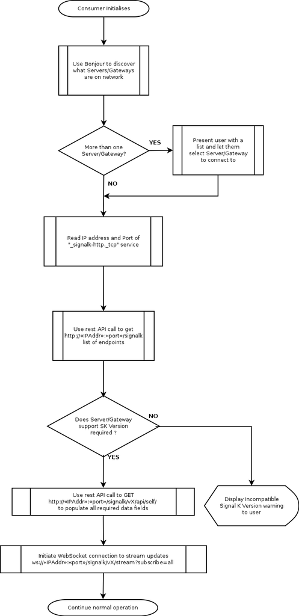

# Alarm, Alert, and Notification Handling

Handling alarms, alerts, and notifications in Signal K is a multi-stage process. Alarms, alerts and notifications are all handled the same way, and are all referred to as alarms below.

We need a flexible model to define alarm conditions, and a standard way to announce and record them.

## Alarm Process

- Define alarm states as zones in the meta object attached to any Signal K value. See [[Metadata for Data Values]]
- If the value is within an alarm zone raise the defined alarm.
- If the value goes out of the zone, remove the alarm by setting its value to null
- Alarms are raised by placing an alarm object in the `vessels.self.notifications` tree

## Expected implementation behaviour

- The server (or device) should monitor the current value and compare it to the defined zones.
- If a value enters an alarm zone, then a key is written to `vessels.self.notifications..`
- If a value leaves an alarm zone, then the key is removed from `vessels.self.notifications..`
- Alarms raised are monitored by an alarm process on the server, which takes appropriate action, sounding alarms, or displaying messages.
- Clients interested in alarms can subcribe to the `vessels.self.notifications...` tree in the usual way and be informed of alarms in the same way as normal signalk keys.
- When an alarms is removed, a delta should be sent to subscribers with the path and a null value.

## Example

eg If we exceed our anchor alarm radius: `vessels.self.navigation.anchor.currentRadius` enters `vessels.self.navigation.anchor.currentRadius.meta.zones : [ {lower: "0", upper: maxRadius, state : "normal"}, {lower: maxRadius, upper: 999999, state: "alarm"}]`

The alarm is : `vessels.self.notifications.navigation.anchor.currentRadius`

The alarm object is

```
{
  "value": {
    "method": ["sound"],
    "state": "alarm",
    "message": "Dragging anchor!"
  },
  "timestamp": "...",
  "$source": "..."
}
```

The server alarm manager will see this new entry and turn on the alarm. Using a manager process allows flexibility in situations where multiple alarms are triggered and your vessel is a mass of flashing and beeping. eg A single 'Pause' button can give you 5-10 minutes to take action, stopping annoying noise, and removing popup messages from screens.

Since the `vessels.self.notifications` tree mirrors the other data in the signal k model, we can selectively watch or react to specific branches or keys. When displaying multiple alarms a screen can also sort and filter them.

## Other Alarms

Above we have discussed monitoring existing values and raising alarms. There are other alarms that must be considered, eg MOB, fire, sinking etc, and misc alerts "GPS signal lost".etc.

The `vessels.[uuid].notifications` tree is the same as any other Signal k branch. Keys can be added and removed as required in the usual way. Since the branch is being monitored we only need to add a key of any sort to create a suitable alarm.

In the case of an emergency, create a unique key: The alarm is : `vessels.[uuid].notifications.[alarm.key]`

The alarm object is

```
{
  "value": {
    "method": ["visual", "sound"],
    "state": "emergency",
    "message": "Man Overboard!"
  },
  ...
}
```

Alarm objects that have been raised this way must be cleared manually, or by the process that created them. You can use any suitable path, keeping in mind the context of the alarm.

eg In the case of an alert, create a unique key by generating a path: The alarm is : `vessels.[uuid].notifications.navigation.gnss`

The alarm object is

```
{
  "value": {
    "method": ["visual"],
    "state": "alert",
    "message": "GPS signal lost!"
  },
  ...
}
```

### Well Known Names

Some alarms are especially important, eg MOB. This is a list of keys for special alarms.

- `..notifications.mob.*`
- `..notifications.fire.*`
- `..notifications.sinking.*`
- `..notifications.flooding.*`
- `..notifications.collision.*`
- `..notifications.grounding.*`
- `..notifications.listing.*`
- `..notifications.adrift.*`
- `..notifications.piracy.*`
- `..notifications.abandon.*`

An example to send an MOB alarm from an N2K source, the gateway would convert and send something like:

```
{
  "context": "vessels.urn:mrn:signalk:uuid:c0d79334-4e25-4245-8892-54e8ccc8021d",
  "updates": [
    {
      "source": {...},
      "timestamp": "2017-08-15T16:00:05.200Z",
      "values": [
        {
          "path": "notifications.mob",
          "value": {
            "message": "MOB",
            "state": "emergency",
            "method": ["visual", "sound"]
          }
        }
      ]
    }
  ]
}
```

The resulting full signalk tree would be:

```
{
  "vessels": {
    "urn:mrn:signalk:uuid:c0d79334-4e25-4245-8892-54e8ccc8021d": {
      "uuid": "...",
      "notifications": {
        "mob": {
          "value": {
            "method": ["visual", "sound"],
            "state": "emergency",
            "message": "Man Overboard!"
          },
          "timestamp": "2017-04-10T08:33:53Z",
          "$source": "..."
        }
      }
    }
  },
  ...
}
```

To clear the alarm condition, send:

```
{
  "context": "vessels.urn:mrn:signalk:uuid:c0d79334-4e25-4245-8892-54e8ccc8021d",
  "updates": [
    {
      "source": {...},
      "timestamp": "2017-08-15T16:00:05.538Z",
      "values": [
        {
          "path": "notifications.mob",
          "value": null
        }
      ]
    }
  ]
}
```

## Multiple cases of the same alarm

Should multiple cases of the same alarm occur (eg a gps loses signal, then a second gps loses signal) the alarms are handled the same as any other multiple values in signalk. However alarms will tend to be re-issued whenever the underlying data changes.

The servers alarm monitoring processes are expected to be smart enough to know that the anchor alarm is triggered, and its not necessary to raise a second copy of the same alarm, after all there is only one boat dragging!

This may be handled differently for notifications. It may be useful to know that your gps's are all failing intermittently, or that . Hence the handling of multiple copies of alarms is an implementation issue, and may vary.

## The key should be unique

If we have an alarm `vessels.self.notifications.navigation.anchor.currentRadius` and we attempt to write another higher in the same tree at `vessels.self.notifications` it must not replace or remove the existing alarm. Since the `meta.zones` structure is only valid on signalk leaf values this occurs naturally in most circumstances. But it is possible to set an alarm value arbitrarily (eg MOB) and care should be taken in implementations that keys do not overwrite existing paths.

# Security

## Communications Security

For privacy and data integrity REST and WebSockets communications should be secured with Transport Layer Security (TLS). All communications over unsecure protocols like HTTP and WebSockets without TLS must be considered insecure even with authentication and access control mechanisms in place.

## Authentication

Authentication for Signal K connections is based on a token carried in the message, or in a cookie or tokens carried in the HTTP `Authorization` header for a HTTP request. The tokens can be of any type.

**Note**: a Signal K server should never simply echo or redistribute a message received without removing or replacing the token. That would result in A's token being sent to B, which allows the B to impersonate A.

There are 3 authentication actions:

- authenticate - login and obtain a token
- logout - invalidate a token
- validate - validate a token with auto-renewal if valid.

All 3 actions can be done via HTTP requests or by sending Signal K messages for non HTTP clients

### Authentication via HTTP

A device or a web client can authenticate with a Signal K server by providing a username and password via a standard HTTP POST request to `/signalk/«version»/auth/login`.

The `«version»` field is the endpoint version identifier chosen by the client from those offered by the server. See the REST API documentation for the structure of these identifiers.

The client may send the login request with a `Content-Type` of `application/json` with the properties `username` and `password` in the body OR with a `Content-Type` of `application/x-www-form-urlencoded` with the `username` and `password` fields.

```json
{
  "username": "me@somecompany.com",
  "password": "my password"
}
```

In response to a valid login, the server shall respond with a 200 (OK) status, set an HTTP session cookie and include the token expiry in seconds and the token value in the body of the response. The response `Content-Type` must be `application/json`.

```json
{
  "timeToLive": 86400,
  "token": "eyJhbGciOiJIUzI1NiIsInR5cCI6IkpXVCJ9.eyJkZXZpY2UiOiIxMjM0LTQ1NjUz"
}
```

In response to invalid login information the server must return HTTP error code 401 (Unauthorized).

If the server does not implement this authentication mechanism it must return HTTP error code 501 (Not Implemented).

### Authentication via WebSockets, TCP, and Similar Transports

The client should send a the following message

```json
{
  "requestId": "1234-45653-343454",
  "login": {
    "username": "john_doe",
    "password": "password"
  }
}
```

If the login is successful, the server will send a response like the following:

```json
{
  "requestId": "1234-45653-343454",
  "state": "COMPLETED",
  "result": 200,
  "login": {
    "timeToLive": 86400,
    "token": "eyJhbGciOiJIUzI1NiIsI...ibtv41fOnJObT4RdOyZ_UI9is8"
  }
}
```

If the login fails, the server will send a response like the following:

```json
{
  "requestId": "1234-45653-343454",
  "state": "COMPLETED",
  "result": 401
}
```

The `result` codes are the same as normally used in HTTP.

### Providing Authorization to the Server in Subsequent Requests

#### Web Based Clients

Web based clients should be sure to include the cookie or `Authorization` HTTP header obtained from the authentication response in all subsequent requests.

#### WebSockets Clients

Clients can include the authentication cookie with the initial request.

Clients can include the `Authorization` HTTP header with the initial connect request. The format of the header should be `Bearer {token}`, for example `Authorization: Bearer eyJhbGciOiJIUzI1NiIsI...ibtv41fOnJObT4RdOyZ_UI9is8`

#### Other Clients

Clients using other kinds of protocols must include the `token` in the Signal K messages they send.

```json
{
  "context": "*",
  "token": "eyJhbGciOiJIUzI1NiIsI...ibtv41fOnJObT4RdOyZ_UI9is8"
  "unsubscribe": [
    {
      "path": "*"
    }
  ]
}
```

### Token Validation

Tokens may have a short expiry time and need to be renewed periodically, or a token's current validity may be unknown.

#### HTTP Clients

To validate a token, a web based client should send an HTTP POST request to `/signalk/«version»/auth/validate` with the token in the cookie, or in the header. If the token is valid, a new token is created with new expiry time, and a new cookie or header set in the response. This effectively renews a token.

The reply message will be returned in any case.

#### Other Clients

Clients using other kinds of protocols can send the following message.

```json
{
  "requestId": "1234-45653-343454",
  "validate": {
    "token": "eyJhbGciOiJIUzI1NiIsI...ibtv41fOnJObT4RdOyZ_UI9is8"
  }
}
```

#### Reply Messages

Any validation request results in one of the following messages

On success:

```
{
  "requestId": "1234-45653-343454",
  "state": "COMPLETED",
  "result": 200,
  "validate": {
    "token": "eyJhbGciOiJIUzI1NiIsI...ibtv41fOnJObT4RdOyZ_UI9is8"
  }
}
```

On error (`result` could be any HTTP code):

```
{
  "requestId": "1234-45653-343454",
  "state": "COMPLETED",
  "result": 401
}
```

### Logout

#### HTTP Clients

To logout, an http based client should send an HTTP PUT request to `/signalk/«version»/auth/logout` with the token in the cookie or in the HTTP header.

#### Other Clients

Clients using other kinds of protocols should send the following message.

```json
{
  "requestId": "1234-45653-343454",
  "logout": {
    "token": "eyJhbGciOiJIUzI1NiIsI...ibtv41fOnJObT4RdOyZ_UI9is8"
  }
}
```

#### Reply Messages

In both cases the reply will be

On success:

```
{
  "requestId": "1234-45653-343454",
  "state": "COMPLETED",
  "result": 200
}
```

On error (`result` could be any HTTP code):

```
{
  "requestId": "1234-45653-343454",
  "state": "COMPLETED",
  "result": 401
}
```

## Device Access

Devices which don’t have any user interaction such as sensors with no input mechanisms should acquire a token using the Access Requests mechanism.

# Request/Response

Requests are used to ask the server to take specific actions. This shows how requests should be formed by the client and how the reponses should look. The details of different request types are defined in other parts of the specification.

## WebSockets and Other Full-duplex Protocols

The exact format of the message for a specific request is defined elsewhere in the specification.

A request must include a client generated `requestId`. The`requestId` is a string and it must be a [version 4 UUID](https://tools.ietf.org/html/rfc4122.html#section-4.4). It will always be included in any response to the request by the server.

For example, a request to PUT a value:

```json
{
  "requestId": "123345-23232-232323",
  "put": {
    "path": "electrical.switches.anchorLight.state",
    "value": 1
  }
}
```

The server will respond with a message which includes the `requestId`, a `state`, and a `statusCode`.

The `state` can be `FAILED`, `PENDING` or `COMPLETED`.

The `statusCode` will be any standard HTTP code including the following.

- 200 - the request was successful
- 400 - something is wrong with the client's request
- 401 - the request has not been applied because it lacks valid authentication credentials
- 403 - the client does not have permission to make the request
- 405 - the server does not support the request
- 502 - something went wrong carrying out the request on the server side
- 504 - timeout on the server side trying to carry out the request

The message can optionally contain an informational, human oriented `message`.

The response object may contain other response data depending on the specific request being made. For example, a response to an authentication request could contain a `login` object.

```json
{
  "requestId": "123345-23232-232323",
  "state": "COMPLETED",
  "statusCode": 200,
  "login": {
    "token": "....."
  }
}
```

A server may respond to a request multiple times depending on how it processes the request.

### PENDING

When a server cannot process the request immediately, it will respond with the `state` PENDING:

```json
{
  "requestId": "123345-23232-232323",
  "state": "PENDING",
  "statusCode": 202
}
```

### FAILED

When a server fails read, or process the request (eg a server error), it will respond with the `state` FAILED:

```json
{
  "requestId": "123345-23232-232323",
  "state": "FAILED",
  "statusCode": 500
}
```

### COMPLETED

When processing is done, but it was not successful:

```json
{
  "requestId": "123345-23232-232323",
  "state": "COMPLETED",
  "statusCode": 502,
  "message": "Unable to contact the light"
}
```

When processing completed successfully:

```json
{
  "requestId": "123345-23232-232323",
  "state": "COMPLETED",
  "statusCode": 200
}
```

### Query a Request

The state of a request can also be found by sending the following:

```json
{
  "requestId": "123345-23232-232323",
  "query": true
}
```

This will result in a reply like the examples above.

## HTTP

HTTP requests use REST API semantics and the responses are similar to the `response` object used above.

One difference is that the `statusCode` value is also sent as the HTTP response code.

The response when a server successfully processes a login request synchronously:

HTTP response code 200

```json
{
  "requestId": "123345-23232-232323",
  "state": "COMPLETED",
  "token": "eyJhbGciOiJIUzI1NiI...aQ8sN1XBAP8bt3tNBT1WiIttm3qM",
  "statusCode": 200
}
```

When a request is PENDING, an HTTP 202 (Accepted) code will be returned and the body will include an `href` to use to check the status of the request. A client should then periodically poll the server to get the status. A client should not poll the server at a rate less than 500ms.

HTTP response code 202

```json
{
  "requestId": "123345-23232-232323",
  "state": "PENDING",
  "href": "/signalk/v1/api/actions/12567",
  "statusCode": 202
}
```

The contents of the response message when checking the status will include the values defined above for the `result` object and may also include extra information related to the request.

For example, the result of a PUT request:

```json
{
   "requestId": "123345-23232-232323",
   "state": "COMPLETED",
   "statusCode": 200
}
```

# PUT Requests

PUT requests are sent to a server to request an action to be taken. For example, a client would use PUT to switch the anchor light on or off, change the heading of the autopilot, or change the current input on a stereo.

Note that this is very different than updating the current state of something. Use a delta update message to report the current / updated value of something, for example to report on the current wind speed from a sensor. See Delta Format

See Request/Response for more details on request/response in Signal K.

## Making a Request To Take an Action

To change a value, a PUT request should be sent via HTTP or using a Signal K **put** delta.

The `source` field is optional. If a request is sent without the source and there is more than one source for the value, the server should respond with a 400 (Bad Request) HTTP status code.

### Via HTTP

```
PUT http://localhost:3000/signalk/v1/api/vessels/self/steering/autopilot/target/headingTrue
{
  "value": 1.52,
  "source": "actisense.204",
}
```

### Via a Delta

```json
{
  "context": "vessels.urn:mrn:signalk:uuid:6b0e776f-811a-4b35-980e-b93405371bc5",
  "requestId": "6b0e776f-811a-4b35-980e-b93405371bc5",
  "put": [{
      "path": "a.b.c",
      "value": 1234
  }]
}
```

The `context` key is optional, and defaults to `vessels.self`, which is the usual case. You can include it to be able to set values on other vessels.

#### NOTE

The above PUT request (v1) uses an array to allow multiple keys in a single PUT. This is deprecated and strongly discouraged as it causes complex problems with the request/response semantics in cases of partial failures. An alternative format has been added to the v1 specification where the PUT request is:

```json
{
  "context": "vessels.urn:mrn:signalk:uuid:6b0e776f-811a-4b35-980e-b93405371bc5",
  "requestId": "6b0e776f-811a-4b35-980e-b93405371bc5",
  "put": {
      "path": "a.b.c",
      "value": 1234
  }
}
```

In the v2 API the array format will be removed. Implementors are recommended to support both in the interim.